# Risk Factor Analysis

## Outcome Variable

**Outcome Variable:** ever_swasted

## Predictor Variables

**Intervention Variable:** perdiar24

**Adjustment Set:**

unadjusted

## Stratifying Variables

The analysis was stratified on these variable(s):

- agecat
- studyid
- country

## Data Summary

| agecat | studyid | country | perdiar24 | ever_swasted | n_cell | n |
| --- | --- | --- | --- | --- | --- | --- |
| 0-24 months (no birth wast) | CMIN | BANGLADESH | 0% | 0 | 9 | 268 |
| 0-24 months (no birth wast) | CMIN | BANGLADESH | 0% | 1 | 0 | 268 |
| 0-24 months (no birth wast) | CMIN | BANGLADESH | (0%, 5%] | 0 | 102 | 268 |
| 0-24 months (no birth wast) | CMIN | BANGLADESH | (0%, 5%] | 1 | 18 | 268 |
| 0-24 months (no birth wast) | CMIN | BANGLADESH | >5% | 0 | 120 | 268 |
| 0-24 months (no birth wast) | CMIN | BANGLADESH | >5% | 1 | 19 | 268 |
| 0-24 months (no birth wast) | CONTENT | PERU | 0% | 0 | 6 | 215 |
| 0-24 months (no birth wast) | CONTENT | PERU | 0% | 1 | 0 | 215 |
| 0-24 months (no birth wast) | CONTENT | PERU | (0%, 5%] | 0 | 141 | 215 |
| 0-24 months (no birth wast) | CONTENT | PERU | (0%, 5%] | 1 | 1 | 215 |
| 0-24 months (no birth wast) | CONTENT | PERU | >5% | 0 | 67 | 215 |
| 0-24 months (no birth wast) | CONTENT | PERU | >5% | 1 | 0 | 215 |
| 0-24 months (no birth wast) | EE | PAKISTAN | 0% | 0 | 212 | 377 |
| 0-24 months (no birth wast) | EE | PAKISTAN | 0% | 1 | 48 | 377 |
| 0-24 months (no birth wast) | EE | PAKISTAN | (0%, 5%] | 0 | 99 | 377 |
| 0-24 months (no birth wast) | EE | PAKISTAN | (0%, 5%] | 1 | 18 | 377 |
| 0-24 months (no birth wast) | EE | PAKISTAN | >5% | 0 | 0 | 377 |
| 0-24 months (no birth wast) | EE | PAKISTAN | >5% | 1 | 0 | 377 |
| 0-24 months (no birth wast) | Guatemala BSC | GUATEMALA | 0% | 0 | 32 | 307 |
| 0-24 months (no birth wast) | Guatemala BSC | GUATEMALA | 0% | 1 | 0 | 307 |
| 0-24 months (no birth wast) | Guatemala BSC | GUATEMALA | (0%, 5%] | 0 | 71 | 307 |
| 0-24 months (no birth wast) | Guatemala BSC | GUATEMALA | (0%, 5%] | 1 | 0 | 307 |
| 0-24 months (no birth wast) | Guatemala BSC | GUATEMALA | >5% | 0 | 202 | 307 |
| 0-24 months (no birth wast) | Guatemala BSC | GUATEMALA | >5% | 1 | 2 | 307 |
| 0-24 months (no birth wast) | iLiNS-Zinc | BURKINA FASO | 0% | 0 | 328 | 2348 |
| 0-24 months (no birth wast) | iLiNS-Zinc | BURKINA FASO | 0% | 1 | 1 | 2348 |
| 0-24 months (no birth wast) | iLiNS-Zinc | BURKINA FASO | (0%, 5%] | 0 | 1275 | 2348 |
| 0-24 months (no birth wast) | iLiNS-Zinc | BURKINA FASO | (0%, 5%] | 1 | 8 | 2348 |
| 0-24 months (no birth wast) | iLiNS-Zinc | BURKINA FASO | >5% | 0 | 726 | 2348 |
| 0-24 months (no birth wast) | iLiNS-Zinc | BURKINA FASO | >5% | 1 | 10 | 2348 |

[output cut: 270 more lines]

The following strata were considered:

- agecat: 0-24 months (no birth wast), studyid: CMIN, country: BANGLADESH
- agecat: 0-24 months (no birth wast), studyid: CONTENT, country: PERU
- agecat: 0-24 months (no birth wast), studyid: EE, country: PAKISTAN
- agecat: 0-24 months (no birth wast), studyid: Guatemala BSC, country: GUATEMALA
- agecat: 0-24 months (no birth wast), studyid: iLiNS-Zinc, country: BURKINA FASO
- agecat: 0-24 months (no birth wast), studyid: JiVitA-4, country: BANGLADESH
- agecat: 0-24 months (no birth wast), studyid: MAL-ED, country: BANGLADESH
- agecat: 0-24 months (no birth wast), studyid: MAL-ED, country: BRAZIL
- agecat: 0-24 months (no birth wast), studyid: MAL-ED, country: INDIA
- agecat: 0-24 months (no birth wast), studyid: MAL-ED, country: NEPAL
- agecat: 0-24 months (no birth wast), studyid: MAL-ED, country: PERU
- agecat: 0-24 months (no birth wast), studyid: MAL-ED, country: SOUTH AFRICA
- agecat: 0-24 months (no birth wast), studyid: MAL-ED, country: TANZANIA, UNITED REPUBLIC OF
- agecat: 0-24 months (no birth wast), studyid: NIH-Birth, country: BANGLADESH
- agecat: 0-24 months (no birth wast), studyid: NIH-Crypto, country: BANGLADESH
- agecat: 0-24 months (no birth wast), studyid: PROVIDE, country: BANGLADESH
- agecat: 0-24 months (no birth wast), studyid: SAS-FoodSuppl, country: INDIA
- agecat: 0-6 months (no birth wast), studyid: CMIN, country: BANGLADESH
- agecat: 0-6 months (no birth wast), studyid: CONTENT, country: PERU
- agecat: 0-6 months (no birth wast), studyid: EE, country: PAKISTAN
- agecat: 0-6 months (no birth wast), studyid: Guatemala BSC, country: GUATEMALA
- agecat: 0-6 months (no birth wast), studyid: JiVitA-4, country: BANGLADESH
- agecat: 0-6 months (no birth wast), studyid: MAL-ED, country: BANGLADESH
- agecat: 0-6 months (no birth wast), studyid: MAL-ED, country: BRAZIL
- agecat: 0-6 months (no birth wast), studyid: MAL-ED, country: INDIA
- agecat: 0-6 months (no birth wast), studyid: MAL-ED, country: NEPAL
- agecat: 0-6 months (no birth wast), studyid: MAL-ED, country: PERU
- agecat: 0-6 months (no birth wast), studyid: MAL-ED, country: SOUTH AFRICA
- agecat: 0-6 months (no birth wast), studyid: MAL-ED, country: TANZANIA, UNITED REPUBLIC OF
- agecat: 0-6 months (no birth wast), studyid: NIH-Birth, country: BANGLADESH
- agecat: 0-6 months (no birth wast), studyid: NIH-Crypto, country: BANGLADESH
- agecat: 0-6 months (no birth wast), studyid: PROVIDE, country: BANGLADESH
- agecat: 0-6 months (no birth wast), studyid: SAS-FoodSuppl, country: INDIA
- agecat: 6-24 months, studyid: CMIN, country: BANGLADESH
- agecat: 6-24 months, studyid: CONTENT, country: PERU
- agecat: 6-24 months, studyid: EE, country: PAKISTAN
- agecat: 6-24 months, studyid: Guatemala BSC, country: GUATEMALA
- agecat: 6-24 months, studyid: iLiNS-Zinc, country: BURKINA FASO
- agecat: 6-24 months, studyid: JiVitA-4, country: BANGLADESH
- agecat: 6-24 months, studyid: MAL-ED, country: BANGLADESH
- agecat: 6-24 months, studyid: MAL-ED, country: BRAZIL
- agecat: 6-24 months, studyid: MAL-ED, country: INDIA
- agecat: 6-24 months, studyid: MAL-ED, country: NEPAL
- agecat: 6-24 months, studyid: MAL-ED, country: PERU
- agecat: 6-24 months, studyid: MAL-ED, country: SOUTH AFRICA
- agecat: 6-24 months, studyid: MAL-ED, country: TANZANIA, UNITED REPUBLIC OF
- agecat: 6-24 months, studyid: NIH-Birth, country: BANGLADESH
- agecat: 6-24 months, studyid: NIH-Crypto, country: BANGLADESH
- agecat: 6-24 months, studyid: PROVIDE, country: BANGLADESH
- agecat: 6-24 months, studyid: SAS-FoodSuppl, country: INDIA

### Dropped Strata

Some strata were dropped due to rare outcomes:

- agecat: 0-24 months (no birth wast), studyid: CMIN, country: BANGLADESH
- agecat: 0-24 months (no birth wast), studyid: CONTENT, country: PERU
- agecat: 0-24 months (no birth wast), studyid: EE, country: PAKISTAN
- agecat: 0-24 months (no birth wast), studyid: Guatemala BSC, country: GUATEMALA
- agecat: 0-24 months (no birth wast), studyid: iLiNS-Zinc, country: BURKINA FASO
- agecat: 0-24 months (no birth wast), studyid: MAL-ED, country: BANGLADESH
- agecat: 0-24 months (no birth wast), studyid: MAL-ED, country: BRAZIL
- agecat: 0-24 months (no birth wast), studyid: MAL-ED, country: INDIA
- agecat: 0-24 months (no birth wast), studyid: MAL-ED, country: NEPAL
- agecat: 0-24 months (no birth wast), studyid: MAL-ED, country: PERU
- agecat: 0-24 months (no birth wast), studyid: MAL-ED, country: SOUTH AFRICA
- agecat: 0-24 months (no birth wast), studyid: MAL-ED, country: TANZANIA, UNITED REPUBLIC OF
- agecat: 0-24 months (no birth wast), studyid: NIH-Birth, country: BANGLADESH
- agecat: 0-24 months (no birth wast), studyid: NIH-Crypto, country: BANGLADESH
- agecat: 0-24 months (no birth wast), studyid: PROVIDE, country: BANGLADESH
- agecat: 0-24 months (no birth wast), studyid: SAS-FoodSuppl, country: INDIA
- agecat: 0-6 months (no birth wast), studyid: CMIN, country: BANGLADESH
- agecat: 0-6 months (no birth wast), studyid: CONTENT, country: PERU
- agecat: 0-6 months (no birth wast), studyid: EE, country: PAKISTAN
- agecat: 0-6 months (no birth wast), studyid: Guatemala BSC, country: GUATEMALA
- agecat: 0-6 months (no birth wast), studyid: JiVitA-4, country: BANGLADESH
- agecat: 0-6 months (no birth wast), studyid: MAL-ED, country: BANGLADESH
- agecat: 0-6 months (no birth wast), studyid: MAL-ED, country: BRAZIL
- agecat: 0-6 months (no birth wast), studyid: MAL-ED, country: INDIA
- agecat: 0-6 months (no birth wast), studyid: MAL-ED, country: NEPAL
- agecat: 0-6 months (no birth wast), studyid: MAL-ED, country: PERU
- agecat: 0-6 months (no birth wast), studyid: MAL-ED, country: SOUTH AFRICA
- agecat: 0-6 months (no birth wast), studyid: MAL-ED, country: TANZANIA, UNITED REPUBLIC OF
- agecat: 0-6 months (no birth wast), studyid: NIH-Birth, country: BANGLADESH
- agecat: 0-6 months (no birth wast), studyid: NIH-Crypto, country: BANGLADESH
- agecat: 0-6 months (no birth wast), studyid: PROVIDE, country: BANGLADESH
- agecat: 0-6 months (no birth wast), studyid: SAS-FoodSuppl, country: INDIA
- agecat: 6-24 months, studyid: CMIN, country: BANGLADESH
- agecat: 6-24 months, studyid: CONTENT, country: PERU
- agecat: 6-24 months, studyid: EE, country: PAKISTAN
- agecat: 6-24 months, studyid: Guatemala BSC, country: GUATEMALA
- agecat: 6-24 months, studyid: MAL-ED, country: BANGLADESH
- agecat: 6-24 months, studyid: MAL-ED, country: BRAZIL
- agecat: 6-24 months, studyid: MAL-ED, country: INDIA
- agecat: 6-24 months, studyid: MAL-ED, country: NEPAL
- agecat: 6-24 months, studyid: MAL-ED, country: PERU
- agecat: 6-24 months, studyid: MAL-ED, country: SOUTH AFRICA
- agecat: 6-24 months, studyid: MAL-ED, country: TANZANIA, UNITED REPUBLIC OF
- agecat: 6-24 months, studyid: NIH-Birth, country: BANGLADESH
- agecat: 6-24 months, studyid: NIH-Crypto, country: BANGLADESH
- agecat: 6-24 months, studyid: PROVIDE, country: BANGLADESH

## Methods Detail

We’re interested in the causal parameters $E[Y_a]$ for all values of $a \in \mathcal{A}$. These parameters represent the mean outcome if, possibly contrary to fact, we intervened to set all units to have $A=a$. Under the randomization and positivity assumptions, these are identified by the statistical parameters $\psi_a=E_W[E_{Y|A,W}(Y|A=a,W)]$. In addition, we’re interested in the mean of $Y$, $E[Y]$ under no intervention (the observed mean). We will estimate these parameters by using SuperLearner to fit the relevant likelihood factors – $E_{Y|A,W}(Y|A=a,W)$ and $p(A=a|W)$, and then updating our likelihood fit using a joint TMLE.

For unadjusted analyses ($W=\{\}$), initial likelihoods were estimated using Lrnr_glm to estimate the simple $E(Y|A)$ and Lrnr_mean to estimate $p(A)$. For adjusted analyses, a small library containing Lrnr_glmnet, Lrnr_xgboost, and Lrnr_mean was used.

Having estimated these parameters, we will then use the delta method to estimate relative risks and attributable risks relative to a prespecified baseline level of $A$.

# Results Detail

## Results Plots

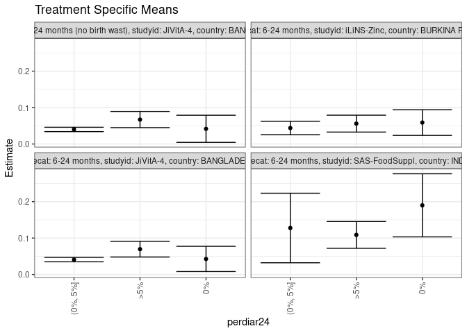

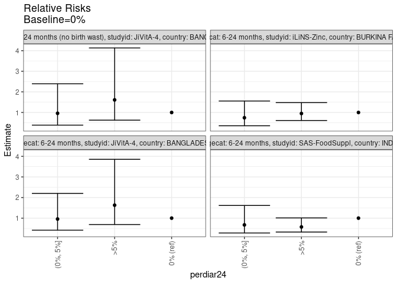

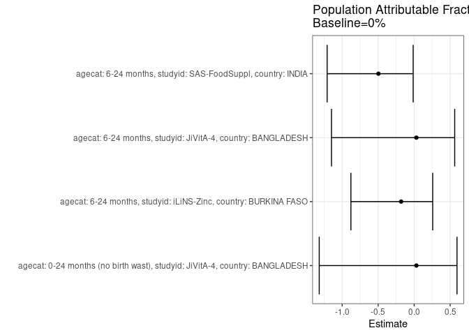

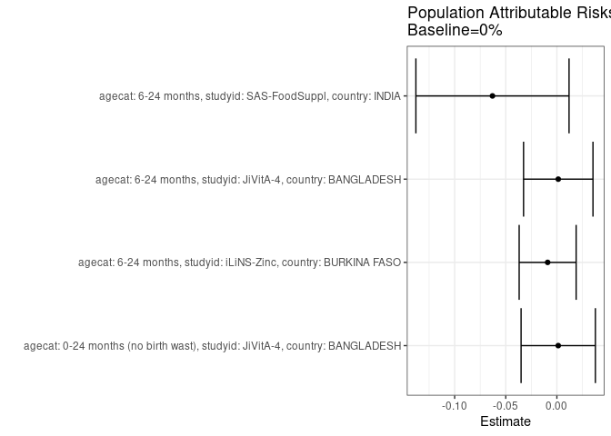

## Results Table

### Parameter: TSM

| agecat | studyid | country | intervention_level | baseline_level | estimate | ci_lower | ci_upper |
| --- | --- | --- | --- | --- | --- | --- | --- |
| 0-24 months (no birth wast) | JiVitA-4 | BANGLADESH | 0% | NA | 0.0416667 | 0.0043929 | 0.0789404 |
| 0-24 months (no birth wast) | JiVitA-4 | BANGLADESH | (0%, 5%] | NA | 0.0400087 | 0.0340677 | 0.0459497 |
| 0-24 months (no birth wast) | JiVitA-4 | BANGLADESH | >5% | NA | 0.0671256 | 0.0448874 | 0.0893639 |
| 6-24 months | iLiNS-Zinc | BURKINA FASO | 0% | NA | 0.0588235 | 0.0235949 | 0.0940521 |
| 6-24 months | iLiNS-Zinc | BURKINA FASO | (0%, 5%] | NA | 0.0438066 | 0.0253066 | 0.0623067 |
| 6-24 months | iLiNS-Zinc | BURKINA FASO | >5% | NA | 0.0559168 | 0.0327664 | 0.0790671 |
| 6-24 months | JiVitA-4 | BANGLADESH | 0% | NA | 0.0426540 | 0.0079861 | 0.0773220 |
| 6-24 months | JiVitA-4 | BANGLADESH | (0%, 5%] | NA | 0.0408296 | 0.0347616 | 0.0468975 |
| 6-24 months | JiVitA-4 | BANGLADESH | >5% | NA | 0.0694915 | 0.0479472 | 0.0910359 |
| 6-24 months | SAS-FoodSuppl | INDIA | 0% | NA | 0.1898734 | 0.1032802 | 0.2764666 |
| 6-24 months | SAS-FoodSuppl | INDIA | (0%, 5%] | NA | 0.1276596 | 0.0321362 | 0.2231830 |
| 6-24 months | SAS-FoodSuppl | INDIA | >5% | NA | 0.1086957 | 0.0719291 | 0.1454623 |

### Parameter: E(Y)

| agecat | studyid | country | intervention_level | baseline_level | estimate | ci_lower | ci_upper |
| --- | --- | --- | --- | --- | --- | --- | --- |
| 0-24 months (no birth wast) | JiVitA-4 | BANGLADESH | NA | NA | 0.0429948 | 0.0372768 | 0.0487128 |
| 6-24 months | iLiNS-Zinc | BURKINA FASO | NA | NA | 0.0497959 | 0.0341610 | 0.0654308 |
| 6-24 months | JiVitA-4 | BANGLADESH | NA | NA | 0.0440147 | 0.0381801 | 0.0498493 |
| 6-24 months | SAS-FoodSuppl | INDIA | NA | NA | 0.1268657 | 0.0942904 | 0.1594410 |

### Parameter: RR

| agecat | studyid | country | intervention_level | baseline_level | estimate | ci_lower | ci_upper |
| --- | --- | --- | --- | --- | --- | --- | --- |
| 0-24 months (no birth wast) | JiVitA-4 | BANGLADESH | 0% | 0% | 1.0000000 | 1.0000000 | 1.000000 |
| 0-24 months (no birth wast) | JiVitA-4 | BANGLADESH | (0%, 5%] | 0% | 0.9602087 | 0.3851919 | 2.393614 |
| 0-24 months (no birth wast) | JiVitA-4 | BANGLADESH | >5% | 0% | 1.6110155 | 0.6279244 | 4.133254 |
| 6-24 months | iLiNS-Zinc | BURKINA FASO | 0% | 0% | 1.0000000 | 1.0000000 | 1.000000 |
| 6-24 months | iLiNS-Zinc | BURKINA FASO | (0%, 5%] | 0% | 0.7447130 | 0.3561830 | 1.557058 |
| 6-24 months | iLiNS-Zinc | BURKINA FASO | >5% | 0% | 0.9505852 | 0.6105530 | 1.479990 |
| 6-24 months | JiVitA-4 | BANGLADESH | 0% | 0% | 1.0000000 | 1.0000000 | 1.000000 |
| 6-24 months | JiVitA-4 | BANGLADESH | (0%, 5%] | 0% | 0.9572262 | 0.4162528 | 2.201263 |
| 6-24 months | JiVitA-4 | BANGLADESH | >5% | 0% | 1.6291902 | 0.6884811 | 3.855241 |
| 6-24 months | SAS-FoodSuppl | INDIA | 0% | 0% | 1.0000000 | 1.0000000 | 1.000000 |
| 6-24 months | SAS-FoodSuppl | INDIA | (0%, 5%] | 0% | 0.6723404 | 0.2799107 | 1.614949 |
| 6-24 months | SAS-FoodSuppl | INDIA | >5% | 0% | 0.5724638 | 0.3244539 | 1.010050 |

### Parameter: PAR

| agecat | studyid | country | intervention_level | baseline_level | estimate | ci_lower | ci_upper |
| --- | --- | --- | --- | --- | --- | --- | --- |
| 0-24 months (no birth wast) | JiVitA-4 | BANGLADESH | 0% | NA | 0.0013281 | -0.0350063 | 0.0376626 |
| 6-24 months | iLiNS-Zinc | BURKINA FASO | 0% | NA | -0.0090276 | -0.0368977 | 0.0188424 |
| 6-24 months | JiVitA-4 | BANGLADESH | 0% | NA | 0.0013607 | -0.0325890 | 0.0353104 |
| 6-24 months | SAS-FoodSuppl | INDIA | 0% | NA | -0.0630077 | -0.1379238 | 0.0119083 |

### Parameter: PAF

| agecat | studyid | country | intervention_level | baseline_level | estimate | ci_lower | ci_upper |
| --- | --- | --- | --- | --- | --- | --- | --- |
| 0-24 months (no birth wast) | JiVitA-4 | BANGLADESH | 0% | NA | 0.0308908 | -1.3187582 | 0.5949674 |
| 6-24 months | iLiNS-Zinc | BURKINA FASO | 0% | NA | -0.1812922 | -0.8787225 | 0.2572340 |
| 6-24 months | JiVitA-4 | BANGLADESH | 0% | NA | 0.0309148 | -1.1483547 | 0.5628626 |
| 6-24 months | SAS-FoodSuppl | INDIA | 0% | NA | -0.4966493 | -1.2090286 | -0.0140019 |